# Data for: Are annual river productivity regimes changing over time?

Nick Marzolf

2023-03-28

# Introduction

To recreate this HTML, load the data files into a folder named ‘Data’ at the same path as the .rmd file, open the .rmd file, and click ‘Knit’.

# Load packages

```r
# data manipulation
library(tidyverse)
library(dplyr)
library(lubridate)
library(purrr)
library(tibble)

# plotting
library(ggplot2)
library(ggpubr)
library(ggExtra)
source("C:/Users/Nick Marzolf/Desktop/Research/R code/theme_nick.R")
theme_set(theme_nick())

# spatial
library(sf)
library(spData)


# statistics
library(lme4)
library(nlme)
library(performance)
library(EnvStats)
library(EflowStats)
library(car)
library(merTools)

# reproducability
library(pander)

# define constants and axis labels
metab_units_area <- (expression(paste('GPP (g C ', m^-2, ' ',y^-1,')', sep = ' ')))

# quotient to convert GPP from O2 to C
# g C = g O2 * (1 mol O2/32 g O2) * (2 mol O/1 mol O2) * (1 mol C/1 mol O) * (12 g C/1 mol C)
rq <- (1/32)*(2/1)*(1/1)*(12/1)
```

# Explore sites

```r
# histogram of watershed areas
table_s1 <- readr::read_csv('data/data_citation/1_site_info.csv')
table_s1
```

```
## # A tibble: 59 × 5
##    `Site Number` Name                                    Latit…¹ Longi…² Drain…³
##            <dbl> <chr>                                     <dbl>   <dbl>   <dbl>
##  1       1400500 Raritan River at Manville NJ               40.6   -74.6  490
##  2       1463500 Delaware River at Trenton NJ               40.2   -74.8 6780
##  3       1480617 West Branch Brandywine Creek at Modena…    40.0   -75.8   55
##  4       1480870 East Branch Brandywine Creek below Dow…    40.0   -75.7   89.9
##  5       1481000 Brandywine Creek at Chadds Ford PA         39.9   -75.6  287
##  6       1608500 SOUTH BRANCH POTOMAC RIVER NEAR SPRING…    39.4   -78.7 1461
##  7       1611500 CACAPON RIVER NEAR GREAT CACAPON WV        39.6   -78.3  675
##  8       1632900 SMITH CREEK NEAR NEW MARKET VA             38.7   -78.6   93.6
##  9       1645704 DIFFICULT RUN ABOVE FOX LAKE NEAR FAIR…    38.9   -77.3    5.49
## 10       1649500 NORTHEAST BRANCH ANACOSTIA RIVER AT RI…    39.0   -76.9   72.8
## # … with 49 more rows, and abbreviated variable names ¹Latitude, ²Longitude,
## #   ³`Drainage Area (km2)`
```

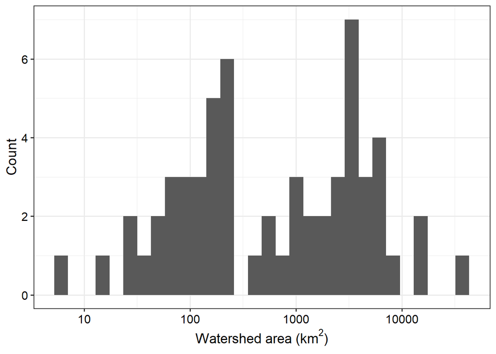

```r
table_s1_plot <- table_s1 %>%
  sf::st_as_sf(.,
               coords = c('Longitude', 'Latitude'),
               crs = 4326)

fig_s1_map <- ggplot()+
  geom_sf(data = world %>%
            dplyr::filter(name_long == 'United States') %>%
            sf::st_set_crs(4326),
          fill = 'white')+
  geom_sf(data = table_s1_plot)+
  coord_sf(xlim = c(-130, -65), ylim = c(23, 55), expand = FALSE)


fig_s1_hist <- ggplot(table_s1,
                      aes(x = `Drainage Area (km2)`*2.58999))+ # convert to km2
  geom_histogram()+
  labs(x = expression(paste('Watershed area (', km^2,')')),
       y = 'Count')+
  scale_x_log10()
fig_s1_hist
```

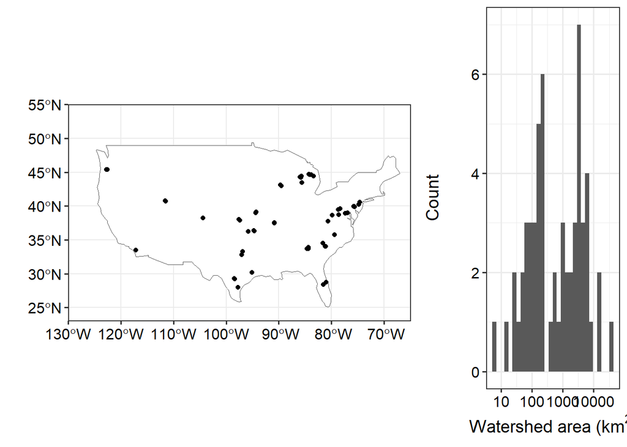

```r
fig_s1 <- cowplot::plot_grid(fig_s1_map,
                             fig_s1_hist,
                             ncol = 2,
                             rel_widths = c(2,1),
                             axis = 'b',
                             align = 'v')
fig_s1
```

```r
ggsave(plot = fig_s1,
       'manuscript/long-term_GPP/figures/fig_s1.png',
       dpi = 600,
       width = 8, height = 3)
```

# Load GPP data

```r
river_metab <- readr::read_csv('data/output_data/good_estimates_2007-2021.csv')
fluxnet_metab <- readr::read_csv('data/output_data/fluxnet_daily_wBiome.csv')
```

# Calculate Annual Productivity

```r
metab_all_daily <- rbind(river_metab %>%
                           dplyr::select(site, date, GPP = GPP) %>%
                           dplyr::mutate(source = 'USGS',
                                         biome = NA),
                         fluxnet_metab %>%
                           dplyr::select(site, date, GPP, biome) %>%
                           dplyr::mutate(source = 'Fluxnet'))

metab_all_annual <- metab_all_daily %>%
  dplyr::mutate(year = lubridate::year(date)) %>%
  dplyr::group_by(source, site, year, biome) %>%
  dplyr::summarise(GPP_ann_C = dplyr::if_else('USGS' %in% source,
                                              sum(GPP*rq, na.rm = TRUE),
                                              sum(GPP, na.rm = TRUE)),
                   GPP_daily_cv = EnvStats::cv(GPP,
                                               na.rm = TRUE, method = 'l.moments')*100)
```

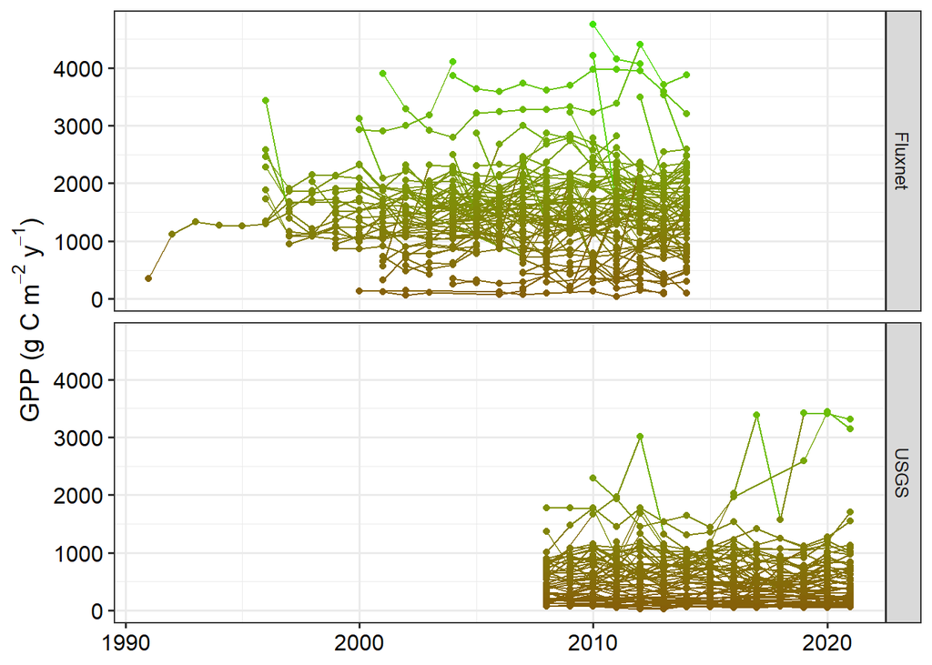

```r
# plot of annual productivity time-series
fig_s2 <- ggplot2::ggplot(metab_all_annual,
                          aes(x = year,
                              y = GPP_ann_C,
                              group = site,
                              color = GPP_ann_C))+
  ggplot2::geom_line()+
  ggplot2::geom_point()+
  ggplot2::scale_color_gradient(name = metab_units_area,
                                low = '#855E09',
                                high = '#40E304')+
  ggplot2::facet_grid(source ~ .)+
  ggplot2::ylab(metab_units_area)+
  ggplot2::theme(axis.title.x = element_blank(),
                 legend.position = 'none')
fig_s2
```

```r
ggsave(plot = fig_s2,
       'manuscript/long-term_GPP/figures/fig_s2.png',
       dpi = 600, width = 6, height = 6)
```

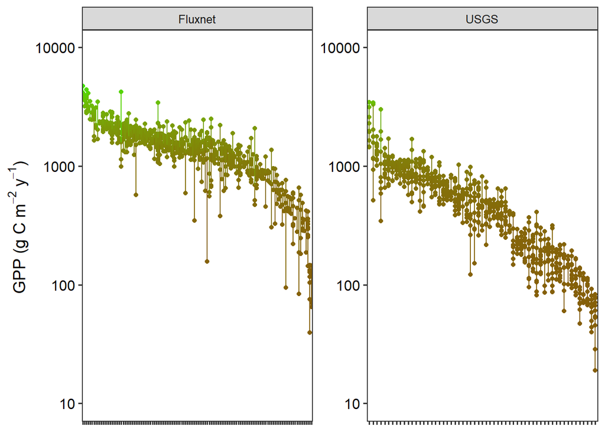

```r
fig_1_top <- ggplot2::ggplot(data = metab_all_annual,
                             ggplot2::aes(x = reorder(site,
                                                      desc(GPP_ann_C)),
                                          y = GPP_ann_C,
                                          color = GPP_ann_C))+
  ggplot2::geom_point()+
  ggplot2::geom_line()+
  ggplot2::ylab(metab_units_area)+
  ggplot2::facet_wrap(. ~ source,
                      scales = 'free')+
  ggplot2::scale_color_gradient(name = metab_units_area,
                                low = '#855E09',
                                high = '#40E304')+
  ggplot2::scale_y_log10(limits = c(10, 10000))+
  ggplot2::theme(axis.title.x = ggplot2::element_blank(),
                 axis.text.x = ggplot2::element_blank(),
                 panel.grid.major = ggplot2::element_blank(),
                 panel.grid.minor = ggplot2::element_blank(),
                 legend.position = 'none')
fig_1_top
```

```r
# calculate long term CV
lt_cv_df <- metab_all_annual %>%
  dplyr::group_by(site, source, biome) %>%
  dplyr::summarise(lt_mean_GPP = mean(GPP_ann_C, na.rm = TRUE),
                   n_obs = length(GPP_ann_C),
                   lt_sd_GPP = sd(GPP_ann_C, na.rm = TRUE),
                   lt_se_GPP = lt_sd_GPP/n_obs,
                   lt_cv = lt_mean_GPP/sd(GPP_ann_C, na.rm = TRUE),
                   yr_range = paste(min(year), max(year), sep = '-'))
# ID the 5 most variable FLUXNET sites
lt_cv_df_sub_flux <- data.frame(lt_cv_df) %>%
  dplyr::arrange(desc(lt_cv)) %>%
  dplyr::filter(source == 'Fluxnet',
                between(row_number(), 1, 5))
lt_cv_df_sub_flux
```

```
##     site  source                        biome lt_mean_GPP n_obs lt_sd_GPP
## 1 IT-SR2 Fluxnet Evergreen Needleleaf Forests    2326.572     2  29.95799
## 2 AU-Wom Fluxnet  Evergreen Broadleaf Forests    2344.812     3  37.78701
## 3 JP-MBF Fluxnet  Deciduous Broadleaf Forests    1059.733     2  19.65161
## 4 IT-Isp Fluxnet  Deciduous Broadleaf Forests    2093.681     2  42.56670
## 5 US-Wi3 Fluxnet  Deciduous Broadleaf Forests    1275.730     2  47.52981
##   lt_se_GPP    lt_cv  yr_range
## 1 14.978997 77.66115 2013-2014
## 2 12.595669 62.05340 2010-2012
## 3  9.825805 53.92603 2004-2005
## 4 21.283352 49.18588 2013-2014
## 5 23.764905 26.84063 2002-2004
```

```r
# ID the 5 most variable river sites
river_names <- readr::read_csv('data/site_info/nwis_site_info.csv') %>%
  dplyr::mutate(site = paste0('nwis_', site_no)) %>%
  dplyr::select(site, station_nm) %>%
  dplyr::mutate(site_nm = str_sub(station_nm, 0, nchar(station_nm) - 3),
                state = str_sub(station_nm, -2, -1),
                clean_name = paste(site_nm, state, sep = ' '))
lt_cv_df_sub_flux_usgs <- data.frame(lt_cv_df) %>%
  dplyr::filter(source == 'USGS') %>%
  dplyr::arrange(desc(lt_cv)) %>%
  dplyr::filter(between(row_number(), 1, 5)) %>%
  dplyr::left_join(river_names, by = 'site')
lt_cv_df_sub_flux_usgs
```

```
##            site source biome lt_mean_GPP n_obs lt_sd_GPP lt_se_GPP     lt_cv
## 1 nwis_10133800   USGS  <NA>    960.7670    11  93.12108  8.465552 10.317396
## 2 nwis_01480870   USGS  <NA>    834.8965    14  83.29684  5.949774 10.023147
## 3 nwis_01649500   USGS  <NA>    628.7665    14  74.15959  5.297113  8.478560
## 4 nwis_02336410   USGS  <NA>    218.5813    14  25.89677  1.849769  8.440486
## 5 nwis_04136000   USGS  <NA>    926.5060    14 115.04259  8.217328  8.053592
##    yr_range                                         station_nm
## 1 2008-2019            EAST CANYON CREEK NEAR JEREMY RANCH, UT
## 2 2008-2021 East Branch Brandywine Creek below Downingtown, PA
## 3 2008-2021  NORTHEAST BRANCH ANACOSTIA RIVER AT RIVERDALE, MD
## 4 2008-2021    NANCY CREEK AT WEST WESLEY ROAD, AT ATLANTA, GA
## 5 2008-2021                    AU SABLE RIVER NEAR RED OAK, MI
##                                           site_nm state
## 1            EAST CANYON CREEK NEAR JEREMY RANCH,    UT
## 2 East Branch Brandywine Creek below Downingtown,    PA
## 3  NORTHEAST BRANCH ANACOSTIA RIVER AT RIVERDALE,    MD
## 4    NANCY CREEK AT WEST WESLEY ROAD, AT ATLANTA,    GA
## 5                    AU SABLE RIVER NEAR RED OAK,    MI
##                                           clean_name
## 1            EAST CANYON CREEK NEAR JEREMY RANCH, UT
## 2 East Branch Brandywine Creek below Downingtown, PA
## 3  NORTHEAST BRANCH ANACOSTIA RIVER AT RIVERDALE, MD
## 4    NANCY CREEK AT WEST WESLEY ROAD, AT ATLANTA, GA
## 5                    AU SABLE RIVER NEAR RED OAK, MI
```

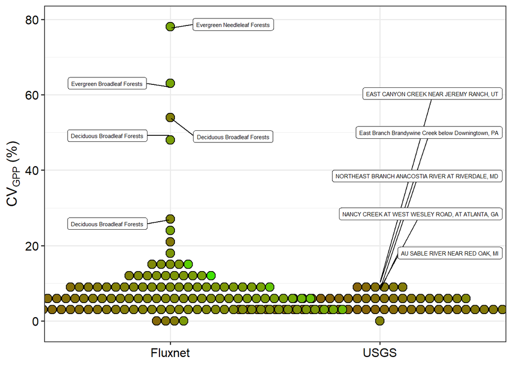

```r
# and plot
fig_1_bottom <- ggplot2::ggplot()+
  ggplot2::geom_dotplot(data = lt_cv_df,
                        aes(x = source, y = lt_cv,
                            fill = lt_mean_GPP,
                            group = lt_mean_GPP),
                        dotsize = 0.8,
                        binaxis='y',
                        stackdir='center',
                        stackgroups=TRUE,
                        method="histodot",
                        binwidth = 3)+
  ggplot2::scale_fill_gradient(name = metab_units_area,
                               low = '#855E09',
                               high = '#40E304')+
  ggplot2::ylab(expression(paste(CV[GPP],' (%)')))+
  ggrepel::geom_label_repel(data = lt_cv_df_sub_flux,
                            aes(x = 1,
                                y = lt_cv,
                                label = biome),
                            nudge_x = c(0.3,-0.3,0.3,-0.3,-0.3),
                            nudge_y = c(1,1,-5,0,-1),
                            size = 2)+
  ggrepel::geom_label_repel(data = lt_cv_df_sub_flux_usgs,
                            aes(x = 2,
                                y = lt_cv,
                                label = clean_name),
                            size = 2,
                            nudge_x = 0.5,
                            nudge_y = c(50,40,30,20,10))+
  ggplot2::theme(axis.title.x = element_blank(),
                 legend.position = 'none')
fig_1_bottom
```

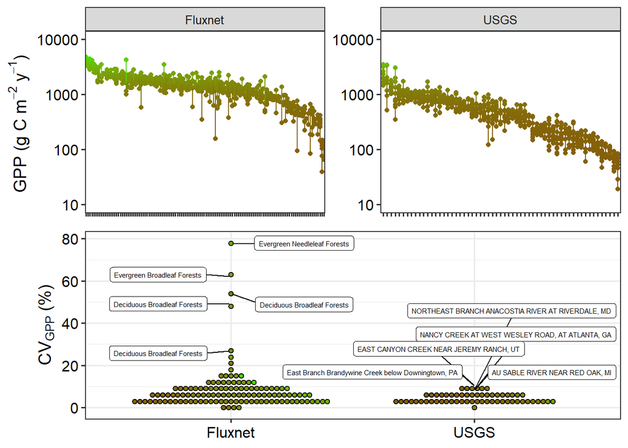

```r
fig_1 <- cowplot::plot_grid(fig_1_top,
                            fig_1_bottom,
                            nrow = 2,
                            ncol = 1,
                            common.legend = TRUE,
                            align = 'hv',
                            axis = 'l')
fig_1
```

```r
ggsave(plot = fig_1,
       'manuscript/long-term_GPP/figures/fig_1.png',
       dpi = 600,
       width = 6.5, height = 5)
```

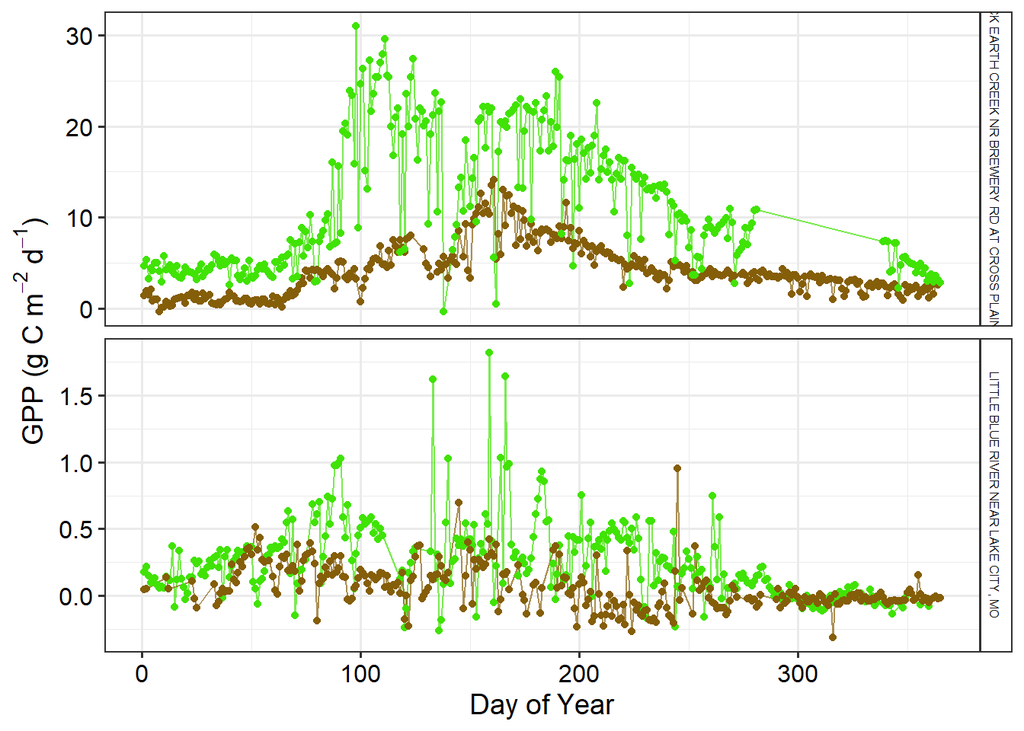

```r
extreme_prod_sites <- lt_cv_df %>%
  data.frame() %>%
  dplyr::filter(source == 'USGS') %>%
  dplyr::arrange(lt_mean_GPP) %>%
  dplyr::slice(c(which.min(lt_mean_GPP), which.max(lt_mean_GPP))) %>%
  dplyr::pull(site)


extreme_site_years <- metab_all_annual %>%
  dplyr::filter(site %in% extreme_prod_sites) %>%
  dplyr::group_by(site) %>%
  dplyr::arrange(GPP_ann_C) %>%
  dplyr::slice(c(which.min(GPP_ann_C), which.max(GPP_ann_C))) %>%
  dplyr::mutate(site_year = paste(site, year, sep = '-'))

extreme_years <- river_metab %>%
  dplyr::mutate(site_year = paste(site, lubridate::year(date), sep = '-')) %>%
  dplyr::filter(site_year %in% extreme_site_years$site_year) %>%
  dplyr::mutate(year = factor(lubridate::year(date)),
                jday = lubridate::yday(date)) %>%
  dplyr::left_join(river_names, 'site') %>%
  dplyr::mutate(clean_name_case = stringr::str_to_upper(clean_name, 'en'))

fig_2 <- ggplot(extreme_years,
                aes(x = jday,
                    y = GPP*rq,
                    color = year))+
  geom_line(alpha = 0.7)+
  geom_point()+
  ggplot2::scale_color_manual(values = c('#40E304','#855E09',
                                         '#855E09','#40E304'))+
  facet_grid(clean_name_case ~ .,
             scales = 'free')+
  labs(x = 'Day of Year',
       y = expression(paste('GPP (g C ', m^-2,' ',d^-1,')')))+
  theme(legend.position = 'none',
        strip.text = element_text(size = 6),
        strip.background = element_rect(fill = 'white'))
fig_2
```

```r
ggsave(plot = fig_2,
       'manuscript/long-term_GPP/figures/fig_2.png',
       dpi = 600,
       width = 5, height = 6)
```

# Productivity trends

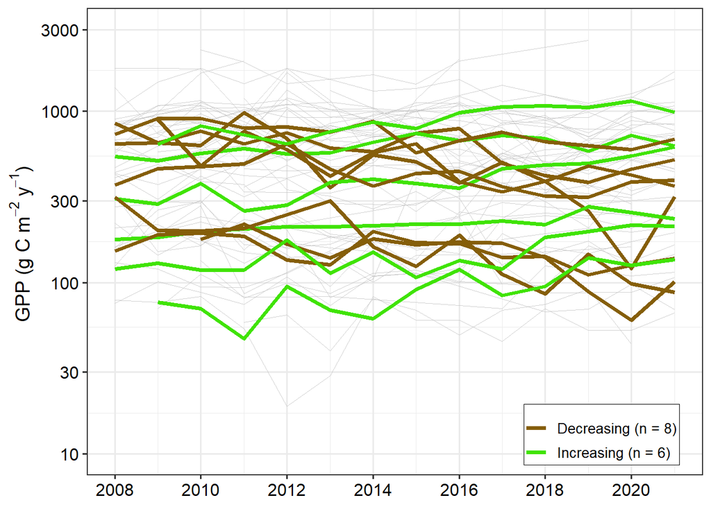

```r
river_metab_ann <- metab_all_annual %>%
  dplyr::filter(source == 'USGS')

annual_C_sum_trends <- river_metab_ann %>%
  dplyr::select(site, year, GPP_ann_C) %>%
  dplyr::group_by(site) %>%
  tidyr::nest() %>%
  dplyr::mutate(sens = purrr::map(data, ~trend::sens.slope(x = .$GPP_ann_C)),
                mk_test = purrr::map(data, ~trend::mk.test(x = .$GPP_ann_C))) %>%
  dplyr::mutate(sens_p = purrr::map(sens, ~.$p.value),
                sens_s = purrr::map_dbl(sens, ~.$estimates),
                mk_p = purrr::map_dbl(mk_test, ~.$p.value),
                mk_s = purrr::map_dbl(mk_test, ~.$estimates['S']),
                sens_sig = ifelse(sens_p <= 0.05, 'significant', 'non-significant'),
                sens_slope = ifelse(sens_s > 0, 'increasing', 'decreasing'),
                mk_sig = ifelse(mk_p <= 0.05, 'significant', 'non-significant'),
                mk_slope = ifelse(mk_s > 0, 'increasing', 'decreasing'))
annual_C_sum_sigs <- annual_C_sum_trends %>%
  dplyr::ungroup() %>%
  dplyr::mutate(sens_p = unlist(sens_p)) %>%
  dplyr::select(site, sens_sig, sens_slope, sens_s, sens_p)

n_sig <- annual_C_sum_sigs %>%
  dplyr::filter(sens_p <= 0.05) %>%
  dplyr::group_by(sens_slope) %>%
  summarise(n = n()) %>%
  data.frame()


river_trends <- river_metab_ann %>%
  dplyr::left_join(annual_C_sum_sigs)
fig_3 <- ggplot2::ggplot(river_trends,
                         ggplot2::aes(x = year,
                                      y = GPP_ann_C,
                                      color = sens_slope))+
  ggplot2::geom_line(aes(group = site),
                     linewidth = 1.25)+
  scale_y_log10(limits = c(10, 3000),
                breaks = c(10,30,100,300,1000,3000),
                labels = c(10,30,100,300,1000,3000))+
  scale_x_continuous(n.breaks = 10)+
  gghighlight::gghighlight(sens_sig == 'significant',
                           use_direct_label = FALSE,
                           keep_scales = TRUE,
                           unhighlighted_params = list(alpha("grey", 0.4),
                                                       linewidth = 0.1))+
  ggplot2::labs(y = metab_units_area)+
  scale_color_manual(name = element_blank(),
                     values = c('#855E09','#40E304'),
                     labels = c(glue::glue('Decreasing (n = ', n_sig[1,2],')'),
                                glue::glue('Increasing (n = ', n_sig[2,2],')')))+
  theme(axis.title.x = element_blank(),
        legend.justification = c(0.95,0.025),
        legend.position = c(0.95, 0.025),
        legend.text = element_text(size = 10),
        legend.background = element_rect(color = 'black',
                                         linewidth = 0.25),
        legend.margin = margin(0, 2, 0.5, 0.1))
fig_3
```

```r
ggsave(plot = fig_3,
       'manuscript/long-term_GPP/figures/fig_3.png',
       dpi = 600,
       width = 6, height = 4)
```

# Drivers of annual productivity

```r
river_light <- readr::read_csv('data/output_data/daily_light_metrics.csv')
library(BernhardtMetabolism)
source('code/functions/fill_and_normalize_metab.R')
river_metab_filled <- fill_and_normalize_metab(river_metab)

river_metab_wLight <- river_metab_filled %>%
  dplyr::left_join(.,
                   river_light,
                   by = c('site', 'date'))


river_metab_ann_drivers <- river_metab_wLight %>%
  dplyr::select(date, site, GPP_filled, discharge, daily_PAR, temp.water) %>%
  dplyr::group_by(site,
                  year = lubridate::year(date)) %>%
  dplyr::summarise(GPP_ann_C = sum(GPP_filled*rq, na.rm = TRUE),         # g C m-2 y-1
                   Q_ann_mean = mean(discharge, na.rm = TRUE),
                   Q_ann_cv = EnvStats::cv(discharge, method = 'l.moments'),
                   light_ann_tot = sum(daily_PAR, na.rm = TRUE),
                   temp_ann_mean = mean(temp.water, na.rm = TRUE)) %>%      # mol m-2 y-1
  dplyr::filter(light_ann_tot != 0)
# all 3 drivers
gpp_mult_reg <- lme4::lmer(data = river_metab_ann_drivers,
                           GPP_ann_C ~ Q_ann_cv + light_ann_tot + temp_ann_mean + (1|site))
summary(gpp_mult_reg)
```

```
## Linear mixed model fit by REML ['lmerMod']
## Formula: GPP_ann_C ~ Q_ann_cv + light_ann_tot + temp_ann_mean + (1 | site)
##    Data: river_metab_ann_drivers
##
## REML criterion at convergence: 8163.6
##
## Scaled residuals:
##     Min      1Q  Median      3Q     Max
## -5.5495 -0.3161 -0.0338  0.2300  7.1118
##
## Random effects:
##  Groups   Name        Variance Std.Dev.
##  site     (Intercept) 205277   453.1
##  Residual              55345   235.3
## Number of obs: 582, groups:  site, 47
##
## Fixed effects:
##                 Estimate Std. Error t value
## (Intercept)    231.69893  179.59361   1.290
## Q_ann_cv      -302.47836  125.75621  -2.405
## light_ann_tot    0.06896    0.01027   6.714
## temp_ann_mean   -3.93229    9.00124  -0.437
##
## Correlation of Fixed Effects:
##             (Intr) Q_nn_c lght__
## Q_ann_cv    -0.310
## light_nn_tt -0.496  0.150
## temp_ann_mn -0.726 -0.087  0.005
## fit warnings:
## Some predictor variables are on very different scales: consider rescaling
```

```r
car::Anova(gpp_mult_reg)
```

```
## Analysis of Deviance Table (Type II Wald chisquare tests)
##
## Response: GPP_ann_C
##                 Chisq Df Pr(>Chisq)
## Q_ann_cv       5.7854  1    0.01616 *
## light_ann_tot 45.0816  1   1.89e-11 ***
## temp_ann_mean  0.1908  1    0.66221
## ---
## Signif. codes:  0 '***' 0.001 '**' 0.01 '*' 0.05 '.' 0.1 ' ' 1
```

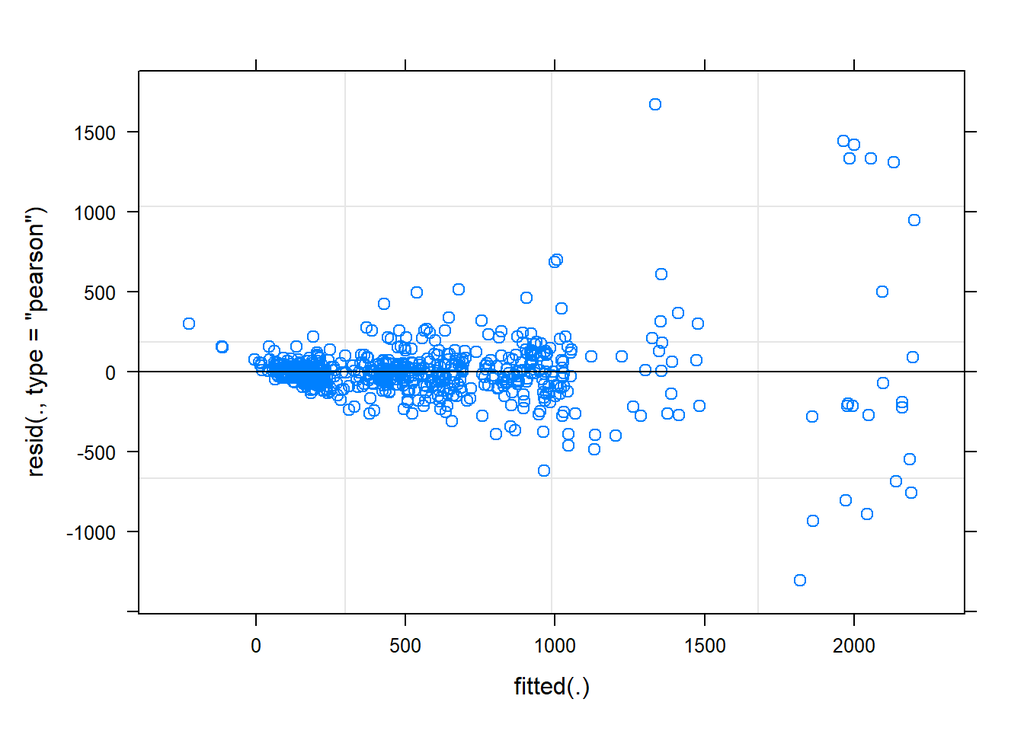

```r
plot(gpp_mult_reg)
```

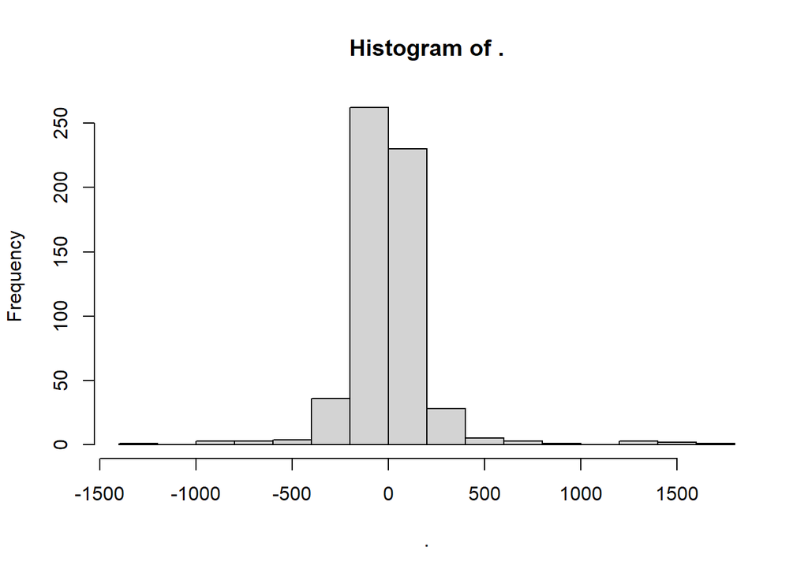

```r
resid(gpp_mult_reg) %>%
  hist()
```

```r
## extract random effects
mult_ranef <- nlme::ranef(gpp_mult_reg)[[1]] %>%
  data.frame() %>%
  tibble::rownames_to_column() %>%
  dplyr::rename(site = rowname,
                ranef = X.Intercept.) %>%
  dplyr::mutate(effect = 'interaction')


## fixed effects
nlme::fixef(gpp_mult_reg)
```

```
##   (Intercept)      Q_ann_cv light_ann_tot temp_ann_mean
##  231.69893011 -302.47835877    0.06896419   -3.93229199
```

```r
# light only
gpp_reg_light <- lme4::lmer(data = river_metab_ann_drivers,
                            GPP_ann_C ~ light_ann_tot + (1|site))
summary(gpp_reg_light)
```

```
## Linear mixed model fit by REML ['lmerMod']
## Formula: GPP_ann_C ~ light_ann_tot + (1 | site)
##    Data: river_metab_ann_drivers
##
## REML criterion at convergence: 8200.4
##
## Scaled residuals:
##     Min      1Q  Median      3Q     Max
## -5.5804 -0.3328 -0.0309  0.2351  7.3021
##
## Random effects:
##  Groups   Name        Variance Std.Dev.
##  site     (Intercept) 226222   475.6
##  Residual              55229   235.0
## Number of obs: 583, groups:  site, 47
##
## Fixed effects:
##                Estimate Std. Error t value
## (Intercept)     4.02299  106.16547   0.038
## light_ann_tot   0.07346    0.01024   7.177
##
## Correlation of Fixed Effects:
##             (Intr)
## light_nn_tt -0.751
## fit warnings:
## Some predictor variables are on very different scales: consider rescaling
```

```r
## light only random effects
light_ranef <- nlme::ranef(gpp_reg_light)[[1]] %>%
  data.frame() %>%
  tibble::rownames_to_column() %>%
  dplyr::rename(site = rowname,
                ranef = X.Intercept.) %>%
  dplyr::mutate(effect = 'light')


# cv Q only
gpp_reg_cvQ <- lme4::lmer(data = river_metab_ann_drivers,
                          GPP_ann_C ~ Q_ann_cv + (1|site))
summary(gpp_reg_cvQ)
```

```
## Linear mixed model fit by REML ['lmerMod']
## Formula: GPP_ann_C ~ Q_ann_cv + (1 | site)
##    Data: river_metab_ann_drivers
##
## REML criterion at convergence: 8205.8
##
## Scaled residuals:
##     Min      1Q  Median      3Q     Max
## -5.8323 -0.2863 -0.0512  0.1970  7.0922
##
## Random effects:
##  Groups   Name        Variance Std.Dev.
##  site     (Intercept) 191056   437.1
##  Residual              60146   245.2
## Number of obs: 582, groups:  site, 47
##
## Fixed effects:
##             Estimate Std. Error t value
## (Intercept)   773.14      85.74   9.017
## Q_ann_cv     -445.23     127.71  -3.486
##
## Correlation of Fixed Effects:
##          (Intr)
## Q_ann_cv -0.658
```

```r
## CV_Q random effects
cvQ_ranef <- nlme::ranef(gpp_reg_cvQ)[[1]] %>%
  data.frame() %>%
  tibble::rownames_to_column() %>%
  dplyr::rename(site = rowname,
                ranef = X.Intercept.) %>%
  dplyr::mutate(effect = 'cv_Q')


# temperature only
gpp_reg_temp <- lme4::lmer(data = river_metab_ann_drivers,
                           GPP_ann_C ~ temp_ann_mean + (1|site))

summary(gpp_reg_temp)
```

```
## Linear mixed model fit by REML ['lmerMod']
## Formula: GPP_ann_C ~ temp_ann_mean + (1 | site)
##    Data: river_metab_ann_drivers
##
## REML criterion at convergence: 8235.4
##
## Scaled residuals:
##     Min      1Q  Median      3Q     Max
## -5.9351 -0.2772 -0.0575  0.1965  7.3757
##
## Random effects:
##  Groups   Name        Variance Std.Dev.
##  site     (Intercept) 211665   460.1
##  Residual              60800   246.6
## Number of obs: 583, groups:  site, 47
##
## Fixed effects:
##               Estimate Std. Error t value
## (Intercept)    667.173    149.065   4.476
## temp_ann_mean   -6.068      8.871  -0.684
##
## Correlation of Fixed Effects:
##             (Intr)
## temp_ann_mn -0.890
```

```r
temp_ranef <- nlme::ranef(gpp_reg_temp)[[1]] %>%
  data.frame() %>%
  tibble::rownames_to_column() %>%
  dplyr::rename(site = rowname,
                ranef = X.Intercept.) %>%
  dplyr::mutate(effect = 'temperature')


# compile and compare model outputs

## Random effects (ie site-level effects)
table_s2 <- list(mult_ranef,
                 light_ranef,
                 temp_ranef,
                 cvQ_ranef) %>%
  reduce(rbind) %>%
  pivot_wider(names_from = effect,
              values_from = ranef)
table_s2[,-1] <- round(table_s2[,-1], 1)
colnames(table_s2) <- c('Site', 'Interaction', 'Light', 'Temperature', 'CVQ')

table_s2
```

```
## # A tibble: 47 × 5
##    Site          Interaction  Light Temperature    CVQ
##    <chr>               <dbl>  <dbl>       <dbl>  <dbl>
##  1 nwis_01463500      1273.  1302.       1392.  1349.
##  2 nwis_01480617       287.   319.        101.    57.2
##  3 nwis_01480870       358.   383.        259.   223.
##  4 nwis_01481000        74.4   99.5        36.6   -9.9
##  5 nwis_01608500       260.   217.        316.   359.
##  6 nwis_01611500       193.   167         159.   192.
##  7 nwis_01632900      -131.  -129.       -138.  -127.
##  8 nwis_01645704       -72.8  -72.5      -456.  -404.
##  9 nwis_02101726       -41.9 -116.       -356   -243.
## 10 nwis_02160700      -398.  -405        -366.  -388.
## # … with 37 more rows
```

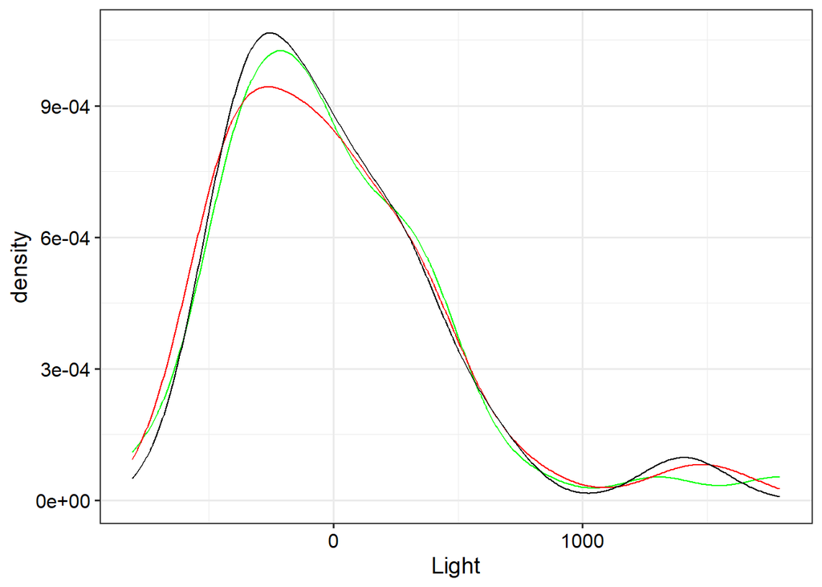

```r
ggplot()+
  geom_density(data = table_s2,
               aes(x = Light), color = 'green')+
  geom_density(data = table_s2,
               aes(x = Temperature), color = 'red')+
  geom_density(data = table_s2,
               aes(x = CVQ), color = 'blue')+
  geom_density(data = table_s2,
               aes(x = CVQ), color = 'black')
```

```r
readr::write_csv(table_s2,
                 'data/data_citation/5_random_effects.csv')

# Compare models by AICw
performance::compare_performance(gpp_reg_temp,
                                 gpp_reg_cvQ,
                                 gpp_reg_light,
                                 gpp_mult_reg)
```

```
## # Comparison of Model Performance Indices
##
## Name          |   Model |  AIC (weights) | AICc (weights) |  BIC (weights) | R2 (cond.) | R2 (marg.) |   ICC |    RMSE |   Sigma
## --------------------------------------------------------------------------------------------------------------------------------
## gpp_reg_temp  | lmerMod | 8259.9 (<.001) | 8260.0 (<.001) | 8277.4 (<.001) |      0.777 |      0.002 | 0.777 | 236.506 | 246.576
## gpp_reg_cvQ   | lmerMod | 8235.5 (<.001) | 8235.6 (<.001) | 8253.0 (<.001) |      0.769 |      0.034 | 0.761 | 235.206 | 245.247
## gpp_reg_light | lmerMod | 8211.4 (<.001) | 8211.4 (<.001) | 8228.8 (0.038) |      0.833 |      0.148 | 0.804 | 225.355 | 235.008
## gpp_mult_reg  | lmerMod | 8196.2 (0.999) | 8196.3 (0.999) | 8222.4 (0.962) |      0.823 |      0.166 | 0.788 | 225.266 | 235.256
```

```r
# predict from best model
pred_river_metab_ann_drivers <- river_metab_ann_drivers %>%
  dplyr::group_by(site, Q_ann_cv, light_ann_tot, temp_ann_mean) %>%
  dplyr::summarise(n = n()) %>%
  dplyr::ungroup() %>%
  dplyr::mutate(GPP_ann_C_pred = stats::predict(gpp_mult_reg,
                                                river_metab_ann_drivers,
                                                re.form = ~(1|site)),
                intervals = merTools::predictInterval(gpp_mult_reg,
                                                      level = 0.95,
                                                      newdata = river_metab_ann_drivers,
                                                      n.sims = 1000,
                                                      stat = 'mean',
                                                      type = 'linear.prediction'),
                GPP_ann_C = river_metab_ann_drivers$GPP_ann_C)
```

[output not shown]

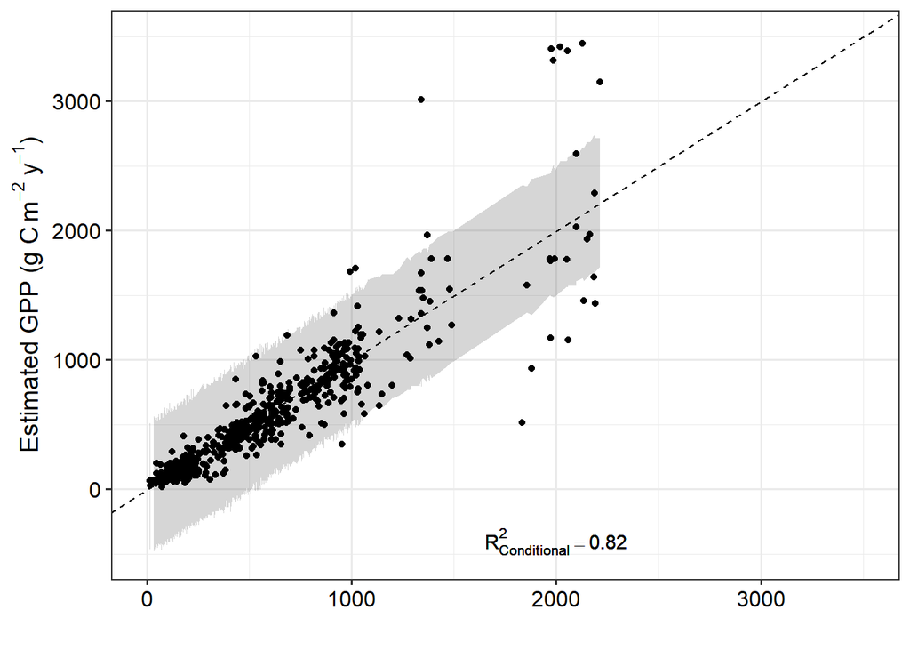

```r
cond_r2 <- round(performance::performance(gpp_mult_reg)$R2_conditional, 2)

line_1 <- expression(paste('Predicted GPP (g C ', m^-2, ' ',y^-1,')'))
line_2 <- expression(paste('GPP ~ MAT + ',CV[Q],' + PAR + (1|site)'))


fig_4 <- ggplot(pred_river_metab_ann_drivers,
                aes(x = intervals$fit))+
  geom_ribbon(aes(ymax = intervals$upr,
                  ymin = intervals$lwr),
              alpha = 0.2)+
  geom_point(aes(y = GPP_ann_C))+
  geom_abline(slope = 1,
              intercept = 0,
              linetype = 'dashed',
              color = 'black')+
  labs(x = "",
       y = expression(paste('Estimated GPP (g C ', m^-2, ' ',y^-1,')')))+
  lims(x = c(0, 3500),
       y = c(-500, 3500))+
  annotate('text',
           x = 2000, y = -400,
           label = bquote(R[Conditional]^2 == .(cond_r2)))
fig_4
```

```r
fig_4 <- cowplot::ggdraw(fig_4)+
  cowplot::draw_label(line_1, x = 0.55, y = 0.06, size = 12)+
  cowplot::draw_label(line_2, x = 0.55, y = 0.02, size = 10)

ggsave(plot = fig_4,
       'manuscript/long-term_GPP/figures/fig_4.png',
       dpi = 600,
       width = 5, height = 4)
```

# Are the drivers changing?

```r
changing_sites <- river_trends %>%
  dplyr::filter(sens_sig == 'significant') %>%
  dplyr::group_by(site) %>%
  dplyr::select(site, sens_slope) %>%
  unique()


changers_drivers <- river_metab_wLight %>%
  dplyr::filter(site %in% changing_sites$site) %>%
  group_by(site, year = lubridate::year(date)) %>%
  summarise(GPP_ann_C = sum(GPP*rq, na.rm = TRUE),
            mat = mean(temp.water, na.rm = TRUE),
            cv_q = EnvStats::cv(discharge, method = 'l.moments'),
            ann_light = sum(daily_PAR, na.rm = TRUE)) %>%
  dplyr::left_join(changing_sites, 'site')
```

```r
mat_trends <- changers_drivers %>%
  dplyr::select(site, year, mat) %>%
  dplyr::group_by(site) %>%
  tidyr::nest() %>%
  dplyr::mutate(sens = purrr::map(data, ~trend::sens.slope(x = .$mat)),
                mk_test = purrr::map(data, ~trend::mk.test(x = .$mat))) %>%
  dplyr::mutate(sens_p = purrr::map(sens, ~.$p.value),
                sens_s = purrr::map_dbl(sens, ~.$estimates),
                mk_p = purrr::map_dbl(mk_test, ~.$p.value),
                mk_s = purrr::map_dbl(mk_test, ~.$estimates['S']),
                sens_sig = ifelse(sens_p <= 0.05, 'significant', 'non-significant'),
                sens_slope = ifelse(sens_s > 0, 'increasing', 'decreasing'),
                mk_sig = ifelse(mk_p <= 0.05, 'significant', 'non-significant'),
                mk_slope = ifelse(mk_s > 0, 'increasing', 'decreasing'))


mat_sigs <- mat_trends %>%
  dplyr::ungroup() %>%
  dplyr::mutate(sens_p = unlist(sens_p)) %>%
  dplyr::select(site, sens_sig, sens_slope, sens_s, sens_p)

n_sig_mat <- mat_sigs %>%
  dplyr::filter(sens_p <= 0.05) %>%
  dplyr::group_by(sens_slope) %>%
  summarise(n = n()) %>%
  data.frame()


cvq_trends <- changers_drivers %>%
  dplyr::select(site, year, cv_q) %>%
  dplyr::group_by(site) %>%
  tidyr::nest() %>%
  dplyr::mutate(sens = purrr::map(data, ~trend::sens.slope(x = .$cv_q)),
                mk_test = purrr::map(data, ~trend::mk.test(x = .$cv_q))) %>%
  dplyr::mutate(sens_p = purrr::map(sens, ~.$p.value),
                sens_s = purrr::map_dbl(sens, ~.$estimates),
                mk_p = purrr::map_dbl(mk_test, ~.$p.value),
                mk_s = purrr::map_dbl(mk_test, ~.$estimates['S']),
                sens_sig = ifelse(sens_p <= 0.05, 'significant', 'non-significant'),
                sens_slope = ifelse(sens_s > 0, 'increasing', 'decreasing'),
                mk_sig = ifelse(mk_p <= 0.05, 'significant', 'non-significant'),
                mk_slope = ifelse(mk_s > 0, 'increasing', 'decreasing'))


cvq_sigs <- cvq_trends %>%
  dplyr::ungroup() %>%
  dplyr::mutate(sens_p = unlist(sens_p)) %>%
  dplyr::select(site, sens_sig, sens_slope, sens_s, sens_p)

n_sig_cvq <- cvq_trends %>%
  dplyr::filter(sens_p <= 0.05) %>%
  dplyr::group_by(sens_slope) %>%
  summarise(n = n()) %>%
  data.frame()


light_trends <- changers_drivers %>%
  dplyr::select(site, year, ann_light) %>%
  dplyr::group_by(site) %>%
  tidyr::nest() %>%
  dplyr::mutate(sens = purrr::map(data, ~trend::sens.slope(x = .$ann_light)),
                mk_test = purrr::map(data, ~trend::mk.test(x = .$ann_light))) %>%
  dplyr::mutate(sens_p = purrr::map(sens, ~.$p.value),
                sens_s = purrr::map_dbl(sens, ~.$estimates),
                mk_p = purrr::map_dbl(mk_test, ~.$p.value),
                mk_s = purrr::map_dbl(mk_test, ~.$estimates['S']),
                sens_sig = ifelse(sens_p <= 0.05, 'significant', 'non-significant'),
                sens_slope = ifelse(sens_s > 0, 'increasing', 'decreasing'),
                mk_sig = ifelse(mk_p <= 0.05, 'significant', 'non-significant'),
                mk_slope = ifelse(mk_s > 0, 'increasing', 'decreasing'))


table_s3 <- changing_sites %>%
  left_join(mat_trends %>%
              dplyr::select(site,
                            mat_mk_p = mk_p),
            'site') %>%
  left_join(cvq_trends %>%
              dplyr::select(site,
                            cvq_mk_p = mk_p),
            'site') %>%
  left_join(light_trends %>%
              dplyr::select(site,
                            light_mk_p = mk_p),
            'site') %>%
  rename(ann_GPP_trend = sens_slope)
table_s3
```

```
## # A tibble: 14 × 5
## # Groups:   site [14]
##    site          ann_GPP_trend mat_mk_p cvq_mk_p light_mk_p
##    <chr>         <chr>            <dbl>    <dbl>      <dbl>
##  1 nwis_01481000 decreasing      0.443    1         1
##  2 nwis_01649500 increasing      0.324    0.228   NaN
##  3 nwis_02168504 decreasing      0.913    0.661     1
##  4 nwis_02336410 increasing      0.0487   0.324   NaN
##  5 nwis_02336526 increasing      0.324    0.381   NaN
##  6 nwis_02337170 decreasing      0.583    0.855     0.951
##  7 nwis_04136500 decreasing      0.274    1         1
##  8 nwis_04137500 decreasing      0.381    1         0.0798
##  9 nwis_06893820 decreasing      0.537    0.631     0.0865
## 10 nwis_07061270 increasing      0.228    0.913     0.913
## 11 nwis_07061290 increasing      0.855    0.0995    0.00279
## 12 nwis_08049500 decreasing      0.760    0.246   NaN
## 13 nwis_08211200 decreasing      0.760    0.502     0.360
## 14 nwis_14211010 increasing      0.0441   0.300   NaN
```

```r
readr::write_csv(table_s3,
                 'data/data_citation/6_table_s3.csv')
```

**R version 4.2.3 (2023-03-15 ucrt)**

**Platform:** x86_64-w64-mingw32/x64 (64-bit)

**locale:** *LC_COLLATE=English_United States.utf8*, *LC_CTYPE=English_United States.utf8*, *LC_MONETARY=English_United States.utf8*, *LC_NUMERIC=C* and *LC_TIME=English_United States.utf8*

**attached base packages:** *stats*, *graphics*, *grDevices*, *utils*, *datasets*, *methods* and *base*

**other attached packages:** *BernhardtMetabolism(v.0.1.1)*, *lmomco(v.2.4.7)*, *zoo(v.1.8-11)*, *pander(v.0.6.5)*, *merTools(v.0.6.1)*, *arm(v.1.13-1)*, *MASS(v.7.3-58.2)*, *car(v.3.1-1)*, *carData(v.3.0-5)*, *EflowStats(v.5.0.2)*, *EnvStats(v.2.7.0)*, *performance(v.0.10.2)*, *nlme(v.3.1-162)*, *lme4(v.1.1-32)*, *Matrix(v.1.5-3)*, *spData(v.2.2.2)*, *sf(v.1.0-11)*, *ggExtra(v.0.10.0)*, *ggpubr(v.0.6.0)*, *lubridate(v.1.9.2)*, *forcats(v.1.0.0)*, *stringr(v.1.5.0)*, *dplyr(v.1.1.0)*, *purrr(v.1.0.1)*, *readr(v.2.1.4)*, *tidyr(v.1.3.0)*, *tibble(v.3.2.0)*, *ggplot2(v.3.4.1)* and *tidyverse(v.2.0.0)*

**loaded via a namespace (and not attached):** *backports(v.1.4.1)*, *blme(v.1.0-5)*, *systemfonts(v.1.0.4)*, *imputeTS(v.3.3)*, *sp(v.1.6-0)*, *splines(v.4.2.3)*, *listenv(v.0.9.0)*, *digest(v.0.6.31)*, *foreach(v.1.5.2)*, *htmltools(v.0.5.4)*, *fansi(v.1.0.4)*, *magrittr(v.2.0.3)*, *tzdb(v.0.3.0)*, *globals(v.0.16.2)*, *vroom(v.1.6.1)*, *xts(v.0.13.0)*, *timechange(v.0.2.0)*, *forecast(v.8.21)*, *tseries(v.0.10-53)*, *colorspace(v.2.1-0)*, *ggrepel(v.0.9.3)*, *textshaping(v.0.3.6)*, *xfun(v.0.37)*, *crayon(v.1.5.2)*, *jsonlite(v.1.8.4)*, *iterators(v.1.0.14)*, *glue(v.1.6.2)*, *gghighlight(v.0.4.0)*, *gtable(v.0.3.2)*, *quantmod(v.0.4.20)*, *abind(v.1.4-5)*, *scales(v.1.2.1)*, *stinepack(v.1.4)*, *mvtnorm(v.1.1-3)*, *DBI(v.1.1.3)*, *rstatix(v.0.7.2)*, *miniUI(v.0.1.1.1)*, *Rcpp(v.1.0.10)*, *xtable(v.1.8-4)*, *gridtext(v.0.1.5)*, *units(v.0.8-1)*, *bit(v.4.0.5)*, *proxy(v.0.4-27)*, *ellipsis(v.0.3.2)*, *pkgconfig(v.2.0.3)*, *farver(v.2.1.1)*, *nnet(v.7.3-18)*, *sass(v.0.4.5)*, *utf8(v.1.2.3)*, *tidyselect(v.1.2.0)*, *labeling(v.0.4.2)*, *rlang(v.1.1.0)*, *later(v.1.3.0)*, *munsell(v.0.5.0)*, *tools(v.4.2.3)*, *cachem(v.1.0.7)*, *cli(v.3.6.0)*, *generics(v.0.1.3)*, *broom(v.1.0.4)*, *evaluate(v.0.20)*, *fastmap(v.1.1.1)*, *goftest(v.1.2-3)*, *ragg(v.1.2.5)*, *yaml(v.2.3.7)*, *knitr(v.1.42)*, *bit64(v.4.0.5)*, *trend(v.1.1.4)*, *future(v.1.32.0)*, *mime(v.0.12)*, *RcppRoll(v.0.3.0)*, *xml2(v.1.3.3)*, *compiler(v.4.2.3)*, *rstudioapi(v.0.14)*, *curl(v.5.0.0)*, *e1071(v.1.7-13)*, *ggsignif(v.0.6.4)*, *bslib(v.0.4.2)*, *stringi(v.1.7.12)*, *highr(v.0.10)*, *lattice(v.0.20-45)*, *classInt(v.0.4-9)*, *nloptr(v.2.0.3)*, *urca(v.1.3-3)*, *vctrs(v.0.6.0)*, *pillar(v.1.8.1)*, *lifecycle(v.1.0.3)*, *furrr(v.0.3.1)*, *lmtest(v.0.9-40)*, *jquerylib(v.0.1.4)*, *cowplot(v.1.1.1)*, *insight(v.0.19.0)*, *lmom(v.2.9)*, *httpuv(v.1.6.9)*, *extraDistr(v.1.9.1)*, *R6(v.2.5.1)*, *promises(v.1.2.0.1)*, *KernSmooth(v.2.23-20)*, *parallelly(v.1.34.0)*, *Lmoments(v.1.3-1)*, *spDataLarge(v.2.0.9)*, *codetools(v.0.2-19)*, *boot(v.1.3-28.1)*, *withr(v.2.5.0)*, *fracdiff(v.1.5-2)*, *broom.mixed(v.0.2.9.4)*, *parallel(v.4.2.3)*, *hms(v.1.1.2)*, *ggtext(v.0.1.2)*, *quadprog(v.1.5-8)*, *grid(v.4.2.3)*, *timeDate(v.4022.108)*, *coda(v.0.19-4)*, *class(v.7.3-21)*, *minqa(v.1.2.5)*, *rmarkdown(v.2.20)*, *TTR(v.0.24.3)* and *shiny(v.1.7.4)*